# Optimización de Producción con Método de Newton-Raphson

Análisis de Ingeniería Industrial

2025-04-05

## 1. Descripción del Problema

Una empresa manufacturera produce un componente especializado para equipo industrial. La empresa enfrenta una estructura de costos compleja debido a varios factores que incluyen economías de escala, fatiga de los trabajadores y degradación del equipo. Para optimizar sus operaciones, la empresa necesita determinar la cantidad óptima de producción que minimiza el costo total.

La función de costo total está modelada como:

$$C(x) = A + Bx + Cx^2 + \frac{D}{x} +
E\ln(x)$$

Donde: - $A$ = Costo de preparación (fijo) - $Bx$ = Costo de materiales (proporcional a la cantidad) - $Cx^2$ = Costos laborales (aumentan con el cuadrado debido a horas extras) - $\frac{D}{x}$ = Distribución de costos fijos (economías de escala) - $E\ln(x)$ = Costos de control de calidad (aumentan logarítmicamente)

## 2. Formulación Matemática

Para encontrar la cantidad óptima de producción $x$ que minimiza el costo, necesitamos encontrar donde la derivada de la función de costo es igual a cero:

$$\frac{dC}{dx} = B + 2Cx - \frac{D}{x^2}
+ \frac{E}{x} = 0$$

Esta es una ecuación no lineal que resolveremos utilizando el método de Newton-Raphson.

## 3. Parámetros del Modelo

Definimos los parámetros específicos para nuestra función de costo:

```r
# Definir los parámetros de costo
A <- 5000    # Costo de preparación ($)
B <- 20      # Costo de materiales ($/unidad)
C <- 0.05    # Factor de costo de horas extras ($/unidad²)
D <- 10000   # Factor de distribución de costos fijos ($ * unidades)
E <- 1000    # Factor de costo de control de calidad ($ * ln(unidades))
```

## 4. Implementación del Método de Newton-Raphson

Primero, definimos la función de costo y sus derivadas:

```r
# Función de costo
funcion_costo <- function(x) {
  return(A + B*x + C*x^2 + D/x + E*log(x))
}

# Primera derivada (lo que queremos encontrar su raíz)
derivada_costo <- function(x) {
  return(B + 2*C*x - D/x^2 + E/x)
}

# Segunda derivada (necesaria para Newton-Raphson)
segunda_derivada_costo <- function(x) {
  return(2*C + 2*D/x^3 - E/x^2)
}
```

Ahora, implementamos el método de Newton-Raphson:

```r
newton_raphson <- function(f, f_prima, x0, tol = 1e-6, max_iter = 100) {
  # Inicializar variables
  x_actual <- x0
  iter <- 0
  error <- Inf

  # Crear dataframe para almacenar iteraciones
  iteraciones <- data.frame(
    iteracion = integer(),
    x = numeric(),
    f_x = numeric(),
    error = numeric()
  )

  # Ejecutar iteraciones
  while (error > tol && iter < max_iter) {
    # Calcular f(x) y f'(x)
    f_x <- f(x_actual)
    f_prima_x <- f_prima(x_actual)

    # Verificar si la derivada está muy cerca de cero
    if (abs(f_prima_x) < 1e-10) {
      stop("La derivada está muy cerca de cero. El método puede no converger.")
    }

    # Calcular la siguiente aproximación
    x_siguiente <- x_actual - f_x / f_prima_x

    # Calcular el error
    error <- abs(x_siguiente - x_actual)

    # Actualizar contador de iteraciones
    iter <- iter + 1

    # Almacenar información de la iteración
    iteraciones <- rbind(iteraciones, data.frame(
      iteracion = iter,
      x = x_actual,
      f_x = f_x,
      error = error
    ))

    # Actualizar para la siguiente iteración
    x_actual <- x_siguiente
  }

  # Verificar si excedimos el máximo de iteraciones
  if (iter >= max_iter && error > tol) {
    warning("Se alcanzó el máximo de iteraciones sin convergencia.")
  }

  # Devolver resultados
  return(list(
    raiz = x_actual,
    iteraciones = iteraciones,
    num_iteraciones = iter,
    convergencia = error <= tol,
    error_final = error
  ))
}
```

## 5. Encontrar la Cantidad Óptima de Producción

Aplicamos el método de Newton-Raphson para encontrar la cantidad óptima:

```r
# Valor inicial
x0 <- 100

# Aplicar Newton-Raphson
resultado <- newton_raphson(
  derivada_costo,
  segunda_derivada_costo,
  x0
)

# Mostrar resultados
cat("Cantidad óptima de producción:", round(resultado$raiz, 2), "unidades\n")
```

```
## Cantidad óptima de producción: 8.5 unidades
```

```r
cat("Número de iteraciones:", resultado$num_iteraciones, "\n")
```

```
## Número de iteraciones: 51
```

```r
cat("Error final:", resultado$error_final, "\n")
```

```
## Error final: 8.069989e-12
```

## 6. Verificación de la Solución

Verificamos que realmente hemos encontrado un mínimo (la segunda derivada debe ser positiva):

```r
segunda_deriv_en_optimo <- segunda_derivada_costo(resultado$raiz)
cat("Segunda derivada en el punto óptimo:", segunda_deriv_en_optimo, "\n")
```

```
## Segunda derivada en el punto óptimo: 18.86467
```

```r
cat("¿Es un mínimo (segunda derivada > 0)?", segunda_deriv_en_optimo > 0, "\n")
```

```
## ¿Es un mínimo (segunda derivada > 0)? TRUE
```

Calculamos el costo mínimo en esta cantidad óptima:

```r
costo_optimo <- funcion_costo(resultado$raiz)
cat("Costo total mínimo: $", round(costo_optimo, 2), "\n")
```

```
## Costo total mínimo: $ 8490.15
```

## 7. Visualización de la Convergencia

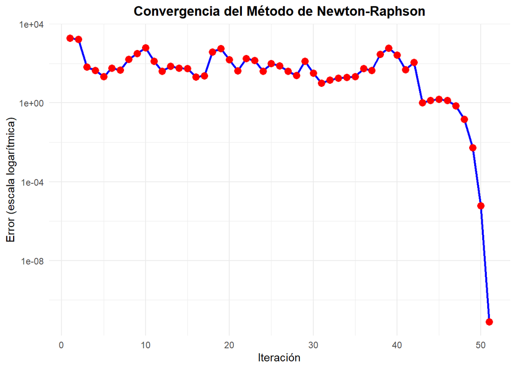

```r
# Graficar la convergencia del método
ggplot(resultado$iteraciones, aes(x = iteracion, y = error)) +
  geom_line(color = "blue", size = 1) +
  geom_point(color = "red", size = 3) +
  scale_y_log10() +
  labs(title = "Convergencia del Método de Newton-Raphson",
       x = "Iteración",
       y = "Error (escala logarítmica)") +
  theme_minimal() +
  theme(plot.title = element_text(hjust = 0.5, face = "bold"))
```

## 8. Visualización de la Función de Costo

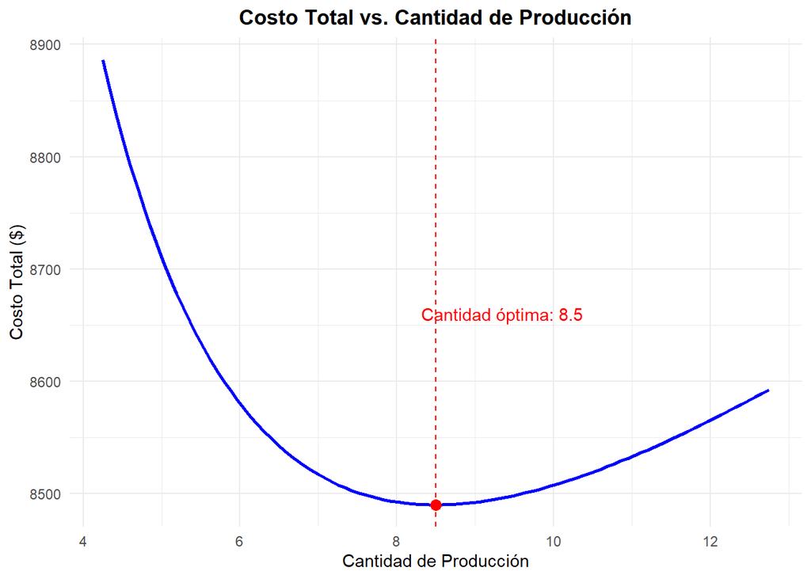

```r
# Crear un rango de cantidades de producción
x_rango <- seq(max(1, resultado$raiz * 0.5), resultado$raiz * 1.5, length.out = 100)

# Calcular costos para cada cantidad
costos <- sapply(x_rango, funcion_costo)

# Crear dataframe para graficar
datos_costo <- data.frame(
  Cantidad = x_rango,
  Costo = costos
)

# Graficar función de costo
ggplot(datos_costo, aes(x = Cantidad, y = Costo)) +
  geom_line(color = "blue", size = 1) +
  geom_vline(xintercept = resultado$raiz, color = "red", linetype = "dashed") +
  geom_point(x = resultado$raiz, y = costo_optimo, color = "red", size = 3) +
  annotate("text", x = resultado$raiz * 1.1, y = costo_optimo * 1.02,
           label = paste("Cantidad óptima:", round(resultado$raiz, 2)),
           color = "red") +
  labs(title = "Costo Total vs. Cantidad de Producción",
       x = "Cantidad de Producción",
       y = "Costo Total ($)") +
  theme_minimal() +
  theme(plot.title = element_text(hjust = 0.5, face = "bold"))
```

## 9. Tabla de Iteraciones

```r
# Formatear la tabla de iteraciones para mostrar
kable(
  resultado$iteraciones,
  col.names = c("Iteración", "Cantidad (x)", "f(x)", "Error"),
  digits = c(0, 2, 6, 8),
  caption = "Iteraciones del Método de Newton-Raphson"
)
```

Iteraciones del Método de Newton-Raphson

| Iteración | Cantidad (x) | f(x) | Error |
| --- | --- | --- | --- |
| 1 | 100.00 | 39.000000 | 1.950000e+03 |
| 2 | -1850.00 | -165.543462 | 1.660338e+03 |
| 3 | -189.66 | -4.516712 | 6.520563e+01 |
| 4 | -124.46 | -1.126177 | 4.493116e+01 |
| 5 | -79.52 | -2.108393 | 2.153854e+01 |
| 6 | -101.06 | -0.980185 | 5.671762e+01 |
| 7 | -157.78 | -2.517692 | 4.599419e+01 |
| 8 | -111.79 | -0.924518 | 1.633667e+02 |
| 9 | 51.58 | 40.786689 | 3.134339e+02 |
| 10 | 365.01 | 59.165937 | 6.368385e+02 |
| 11 | -271.82 | -10.996663 | 1.286605e+02 |
| 12 | -143.16 | -1.789312 | 4.030517e+01 |
| 13 | -102.86 | -0.953127 | 7.390832e+01 |
| 14 | -176.77 | -3.653929 | 5.675944e+01 |
| 15 | -120.01 | -1.027930 | 5.412131e+01 |
| 16 | -65.89 | -4.069826 | 2.032024e+01 |
| 17 | -86.21 | -1.566286 | 2.381181e+01 |
| 18 | -110.02 | -0.917399 | 3.879163e+02 |
| 19 | 277.90 | 51.258718 | 5.825974e+02 |
| 20 | -304.70 | -13.859611 | 1.565668e+02 |
| 21 | -148.13 | -2.019709 | 4.183726e+01 |
| 22 | -106.30 | -0.922340 | 1.788281e+02 |
| 23 | -285.12 | -12.142637 | 1.398335e+02 |
| 24 | -145.29 | -1.885526 | 4.089516e+01 |
| 25 | -104.40 | -0.936075 | 1.002660e+02 |
| 26 | -204.66 | -5.590978 | 7.576599e+01 |
| 27 | -128.90 | -1.249661 | 4.101260e+01 |
| 28 | -87.88 | -1.461857 | 2.480084e+01 |
| 29 | -112.68 | -0.930315 | 1.280300e+02 |
| 30 | 15.35 | 44.236194 | 3.188370e+01 |
| 31 | -16.54 | -78.690682 | 9.862153e+00 |
| 32 | -26.40 | -34.868790 | 1.439691e+01 |
| 33 | -40.80 | -14.600217 | 1.835568e+01 |
| 34 | -59.15 | -5.678856 | 2.010679e+01 |
| 35 | -79.26 | -2.134660 | 2.148495e+01 |
| 36 | -100.74 | -0.985843 | 5.449703e+01 |
| 37 | -155.24 | -2.380615 | 4.478227e+01 |
| 38 | -110.46 | -0.918623 | 2.871006e+02 |
| 39 | 176.64 | 43.004904 | 6.007953e+02 |
| 40 | -424.15 | -24.828524 | 2.636300e+02 |
| 41 | -160.52 | -2.670021 | 4.737743e+01 |
| 42 | -113.15 | -0.933862 | 1.155891e+02 |
| 43 | 2.44 | -1245.265329 | 1.034823e+00 |
| 44 | 3.48 | -518.661184 | 1.320865e+00 |
| 45 | 4.80 | -205.315967 | 1.491989e+00 |
| 46 | 6.29 | -73.073831 | 1.324912e+00 |
| 47 | 7.62 | -20.334797 | 7.228478e-01 |
| 48 | 8.34 | -3.051774 | 1.510102e-01 |
| 49 | 8.49 | -0.099508 | 5.262670e-03 |
| 50 | 8.50 | -0.000115 | 6.070000e-06 |
| 51 | 8.50 | 0.000000 | 0.000000e+00 |

## 10. Análisis de Sensibilidad

Analizamos cómo la cantidad óptima cambia cuando los parámetros de costo varían:

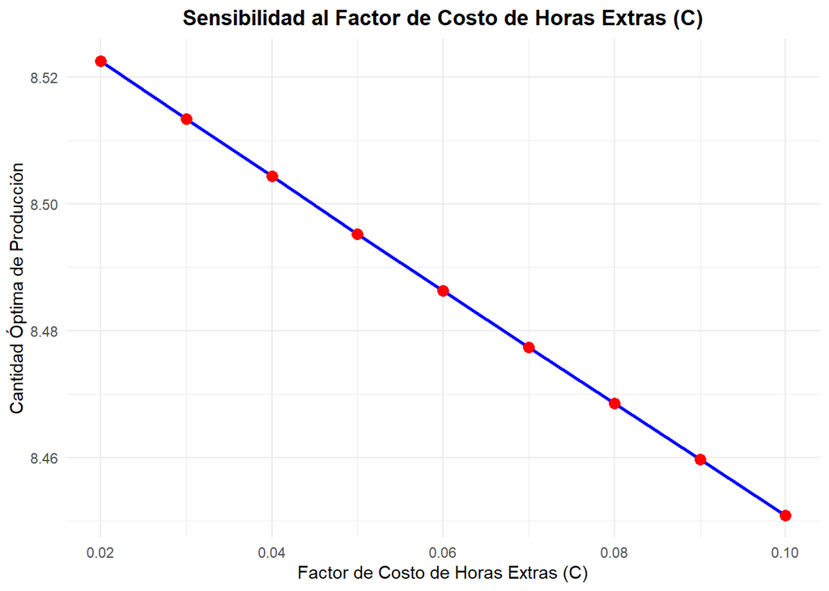

```r
# Función para encontrar la cantidad óptima con diferentes valores de parámetros
encontrar_optimo <- function(A_val, B_val, C_val, D_val, E_val) {
  # Definir nueva función derivada con parámetros actualizados
  nueva_derivada <- function(x) {
    return(B_val + 2*C_val*x - D_val/x^2 + E_val/x)
  }

  # Definir nueva función segunda derivada
  nueva_segunda_derivada <- function(x) {
    return(2*C_val + 2*D_val/x^3 - E_val/x^2)
  }

  # Encontrar cantidad óptima
  resultado_nuevo <- newton_raphson(
    nueva_derivada,
    nueva_segunda_derivada,
    resultado$raiz  # Usar resultado anterior como punto inicial
  )

  return(resultado_nuevo$raiz)
}

# Analizar sensibilidad al parámetro C (costo de horas extras)
valores_C <- seq(0.02, 0.1, by = 0.01)
cantidades_optimas <- sapply(valores_C, function(c_val) {
  encontrar_optimo(A, B, c_val, D, E)
})

# Crear dataframe para graficar
datos_sensibilidad <- data.frame(
  valores_C = valores_C,
  Cantidad_Optima = cantidades_optimas
)

# Graficar análisis de sensibilidad
ggplot(datos_sensibilidad, aes(x = valores_C, y = Cantidad_Optima)) +
  geom_line(color = "blue", size = 1) +
  geom_point(color = "red", size = 3) +
  labs(title = "Sensibilidad al Factor de Costo de Horas Extras (C)",
       x = "Factor de Costo de Horas Extras (C)",
       y = "Cantidad Óptima de Producción") +
  theme_minimal() +
  theme(plot.title = element_text(hjust = 0.5, face = "bold"))
```

## 11. Conclusión

Para una implementación real, la empresa debería: 1. Validar la función de costo con datos históricos 2. Actualizar periódicamente los parámetros a medida que cambien las condiciones del negocio 3. Incorporar restricciones adicionales como capacidad de producción y límites de inventario